# Results for Linear Combinations of Random Variables

April 05, 2020

**Section 4.9**

### Key Results for Chapter 4

Let \( \small X \) and \( \small Y \) be random variables and \( a, b, c, d \) be constants.

(1)

\[ E[aX+bY+c] = aE[X] + bE[Y]+c \]

(2)

\[ V[X+Y] = V[X] + V[Y] + 2Cov[X,Y] \]

(3)

\[ V[X-Y] = V[X] + V[Y] - 2Cov[X,Y] \]

(4)

\[ V[aX + bY + c] = a^2V[X] + b^2V[Y] + 2abCov[X,Y] \]

(5)

\[ Cov[aX+b, cY+d] = acCov[X,Y] \]

(6)

\[ Cov[X,X] = V[X] \]

### Key Results for Chapter 4

\[ E\left[\sum\limits_{i=1}^na_iX_i\right] = \sum\limits_{i=1}^na_iE\left[X_i\right] \]

### Example

Consider rolling a fair 4-sided die twice. Let \( \small X_1 \) be the outcome of the first roll, and \( \small X_2 \) the outcome of the second. We have studied this problem enough to know that \( \small X_1, X_2 \) are independent and therefore uncorrelated.

We consider statistics involved in ordering; the simpliest being the \( max \) and \( min \). Let

\[ V = min\{X1, X2\} \quad \text{ and } \quad W = max\{X1, X2\} \]

The random variable \( V \) has the following pmf

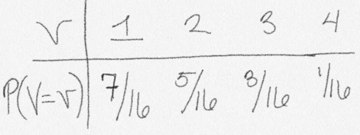

The random variable \( W \) has the following pmf

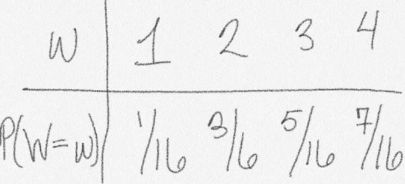

### Example

We should now feel comfortable with finding the *expectation* and *variance* of these random variables.

\[ E[V] = \frac{15}{8} \quad V[V] = \frac{55}{65} \]

\[ E[W] = \frac{25}{8} \quad V[W] = \frac{55}{65} \]

\[ Cov[V,W] = \frac{25}{64} \]

This value is positive; if the \( min \) gets larger, then we expect that the \( max \) gets larger.

Now, we want to describe the random variable \( R = W - V \), also known as the **Range**. We can apply our general formulas.

\[ E[R] = E[W-V] = E[W] - E[V] = \frac{25}{8} - \frac{15}{8} = \frac{5}{4} = 1.25 \]

\[ \begin{aligned} V[R] &= V[W-V] = V[W] + V[V] - 2Cov[W,V] \\ &= 2\frac{55}{64} - 2\frac{25}{64} = \frac{15}{16} = 0.9375 \end{aligned} \]